# AR1 Examples

Shirley He

# 1 Notebook Contents

# 2 Introduction to AR(1)

An $AR(p)$ model is an autoregressive model where a number of lagged values of $Y_t$ are used as the predictor variables.  
The value $p$ is called the order.

One of the most basic linear time series models is the autoregressive model of order 1.

This is $AR(1)$.
$$Y_t = \phi_0 + \phi_1 Y_{t-1} + \epsilon_t$$

$$\epsilon_t \sim WN(0, \sigma^2_\epsilon)$$
where $\epsilon_t$ is a white noise process with mean 0 and variance $\sigma^2 _\epsilon$

The outcome variable $Y_t$ in a first order AR process at $t$ is related only to the value of the variable at one lag (the value at $t-1$).  
If we had a $AR(2)$ model, the outcome would be related to two periods apart and so on.

# 3 Stationary AR(1)

A simple example of a stationary process is a Gaussian white noise process, where each observation $x_t$ is iid $\mathcal{N}(0,\sigma^2)$.

Here we will simulate Gaussian white noise and plot it.  
(Most stationary time series plots will look similar to this.)

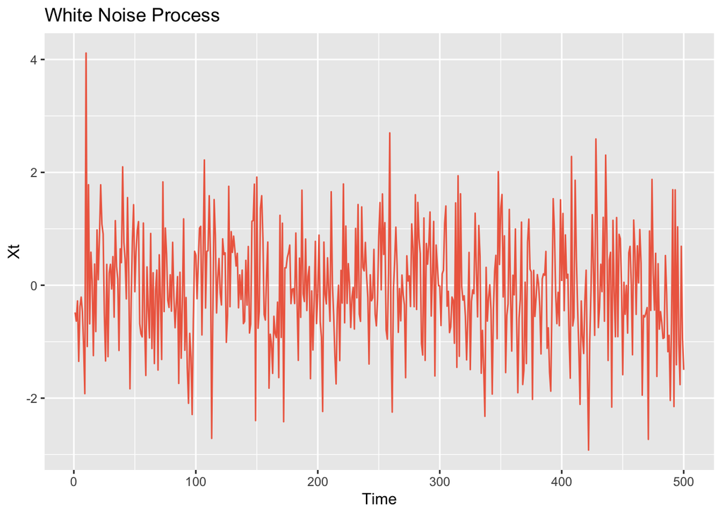

```r
#clean up and loac libraries
rm( list=ls() )
library(ggplot2)

T  <- 500
white_noise_df <- data.frame(T, rnorm(T,0,1))

colnames(white_noise_df) <- c("T", "white_noise")

ggplot(data = white_noise_df, aes(x=seq(T), y=white_noise)) +
  geom_line(color="coral2") +
  ggtitle("White Noise Process") +
  xlab("Time") +
  ylab("Xt")
```

The autoregressive model of order 1 is $Y_t = \phi_0 + \phi_1 Y_{t-1} + \epsilon_t$  
The white noise is gaussian  
$\phi_1 <= 1$

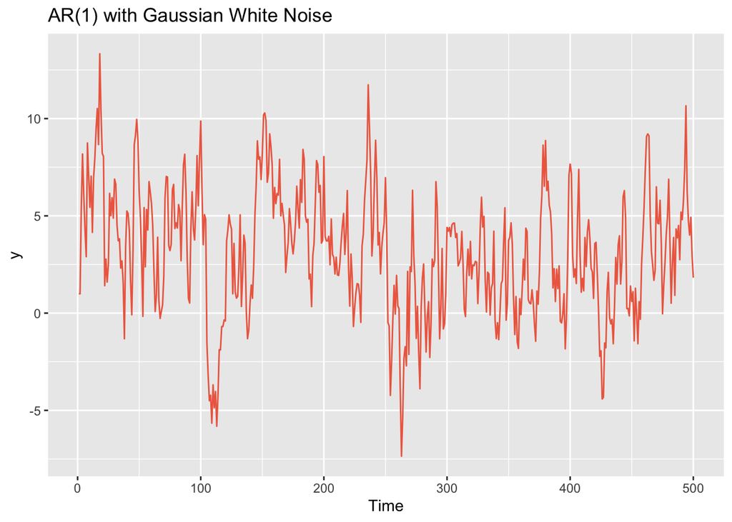

```r
phi0  <- 0.5
phi1  <- 0.8
sd_of_eps  <- sqrt(4)
y    <- rep(0,T)

#gaussian white noise
eps  <- rnorm(T,0,sd_of_eps)

#for every day after day 1, we compute the autoregressive model of order 1.
y[1] <- 1
for( t in 2:T ){
    y[t] <- phi0 + phi1*y[t-1] + eps[t]
}

y_df <- data.frame(y)
ggplot(data=y_df, aes(x=seq(T), y=y)) +
  geom_line(color = "coral2") +
  ggtitle("AR(1) with Gaussian White Noise") +
  xlab("Time") +
  ylab("y")
```

# 4 Nonstationary AR(1)

The white noise is still gaussian  
But $\phi_1 > 1$ so we have a non-stationary process.

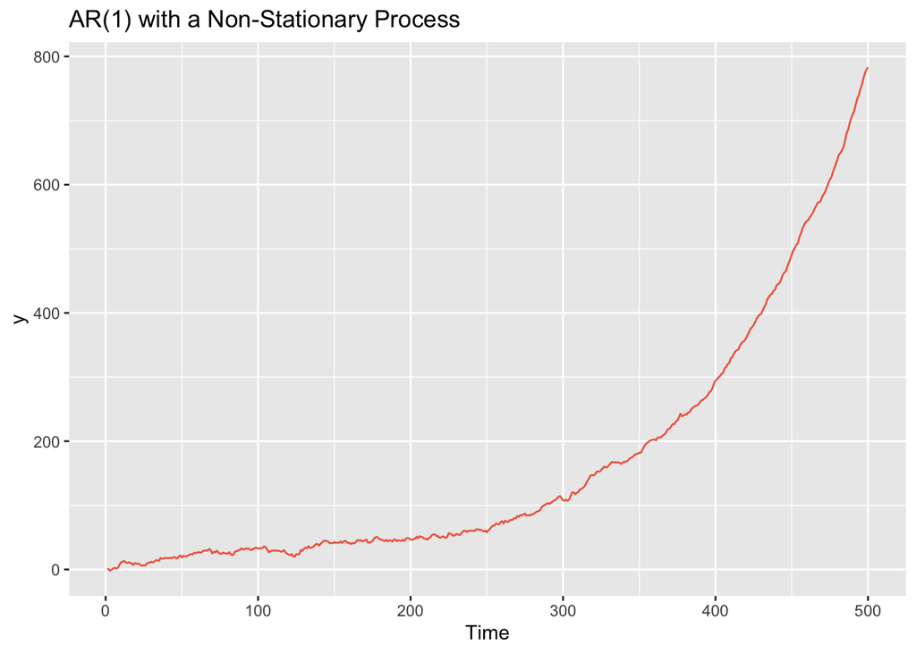

```r
phi0 <- 0.0
phi1 <- 1.01
sd_of_eps <- sqrt(4)
y    <- rep(0,T)

#gaussian white noise
eps  <- rnorm(T,0,sd_of_eps)

#for every day after day 1, we compute the autoregressive model of order 1.
y[1] <- 1
for( t in 2:T ){
    y[t] <- phi0 + phi1*y[t-1] + eps[t]
}

y_df <- data.frame(y)
ggplot(data = y_df, aes(x=seq(T), y=y)) +
  geom_line(color = "coral2") +
  ggtitle("AR(1) with a Non-Stationary Process") +
  xlab("Time") +
  ylab("y")
```

# 5 Unconditional Distribution AR(1)

**Kernel Density Estimation (KDE)** is a non-parametric way to estimate the probability density function that generated a dataset.

## 5.1 Histogram

Before we use KDE, we can plot a histogram to have a first look at the underlying frequency distribution.

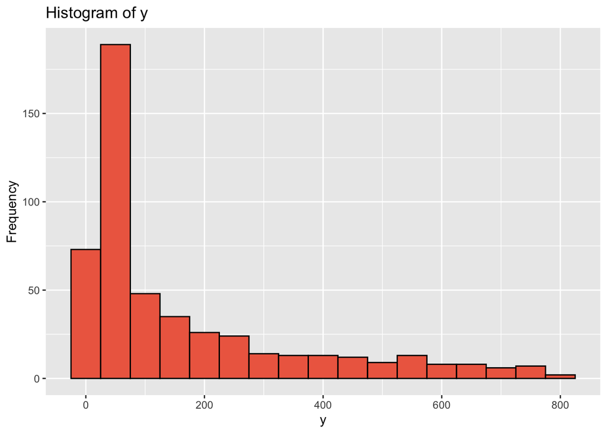

```r
ggplot(data = y_df, aes(x=y)) +
  geom_histogram(binwidth = 50, color="black", fill="coral2") +
  ggtitle("Histogram of y") +
  ylab("Frequency")
```

## 5.2 Kernel Density Estimator

```r
#R function "density" computes kernel density estimates
kernel <- density(y)
kernel
```

```
##
## Call:
##  density.default(x = y)
##
## Data: y (500 obs.);  Bandwidth 'bw' = 38.89
##
##        x                y
##  Min.   :-118.6   Min.   :6.090e-07
##  1st Qu.: 136.0   1st Qu.:2.674e-04
##  Median : 390.6   Median :4.479e-04
##  Mean   : 390.6   Mean   :9.808e-04
##  3rd Qu.: 645.2   3rd Qu.:1.079e-03
##  Max.   : 899.8   Max.   :5.264e-03
```

We will need the unconditional mean and variance of the AR(1) process.
$$Y_t = \phi_0 + \phi_1 Y_{t-1} + \epsilon_t , \epsilon_t \sim WN(0, \sigma^2_\epsilon)$$

$$\epsilon_t \sim WN(0, \sigma^2_\epsilon)$$

The expecation of $Y_t$ is:
$$E(Y_t) = \frac{\phi_0}{1-\phi_1}$$

The variance of $Y_t$ is:
$$Var(Y_t) = \frac{\sigma^2_\epsilon}{1 - \phi_1^2}$$

```r
mu    <- phi0/(1-phi1)
sigma <- sd_of_eps/sqrt(1-phi1**2)
```

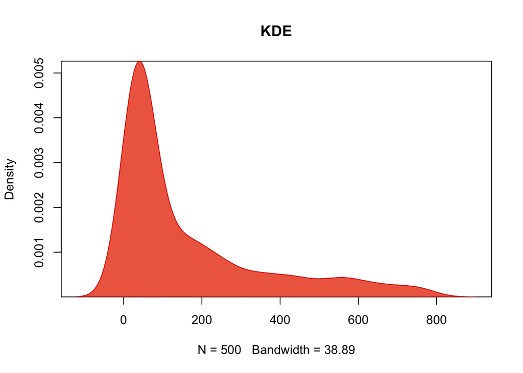

```r
plot( kernel , main='KDE' , yaxs='i')
polygon( kernel , col="coral2" , border='red2' )
lines( seq(-10,20,0.1) , dnorm( seq(-10,20,0.1) , mu , sigma ) , col='coral2' ,lwd=4)
```

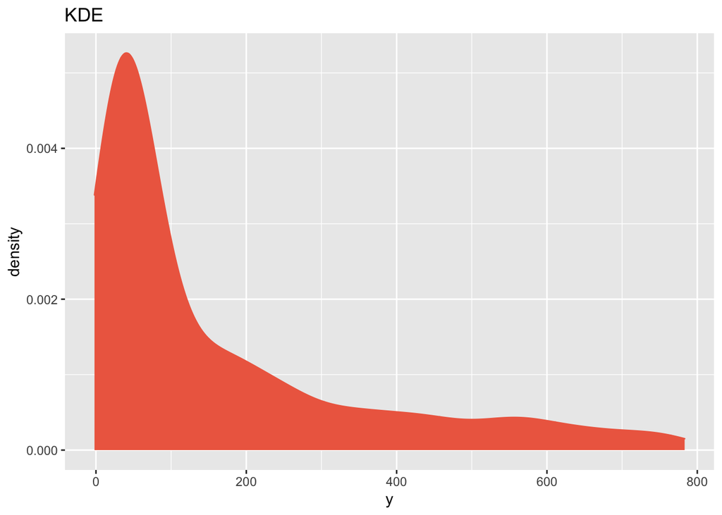

```r
#ggplot is alternative way to plot - KDE is built in to geom_density()
ggplot(data = y_df, mapping = aes(x=y)) + geom_density(color="coral2", fill="coral2") +
  ggtitle("KDE")
```

# 6 Conditional Distribution AR(1)

Considering that we have an AR(1) process, we can plot the conditional distribution of $X_t$ given the information set $\Phi_{t-1}$.

The conditional distribution of $X_t$ is
$$X_{t} \mid \Phi_{t-1} \sim D\left(\phi_{0}+\phi_{1} X_{t-1}, \sigma^{2}\right)$$

```r
mu    <- phi0/(1-phi1)
sigma <- sd_of_eps/sqrt(1-phi1**2)
```

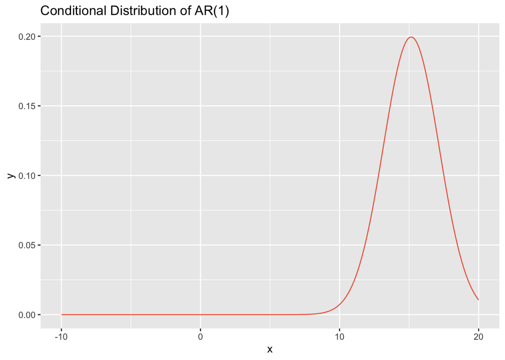

```r
df <- data.frame(seq(-10, 20, 0.1), dnorm(seq(-10,20,0.1) , phi0+phi1*15 , sd_of_eps))
colnames(df) <- c("x", "y")

ggplot(data = df, aes(x=x, y=y)) +
  geom_line(color="coral2") +
  ggtitle("Conditional Distribution of AR(1)")
```

# 7 ACF and PACF

**ACF** is an autocorrelation function that gives the values of autocorrelation of a series with it’s lagged values.  
It shows us how much the present value of the series is related to past values.

**PACF** is a partial autocorrelation function that gives the values of autocorrelation of a series with it’s lagged values, after we have removed the effects that were already explained in earlier lags.

We will plot the ACF and PACF of the AR(1) below

## 7.1 ACF AR(1)

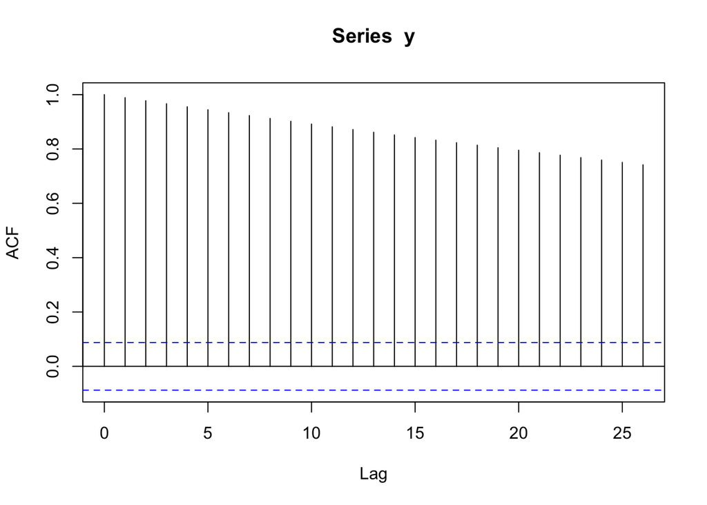

```r
acf(y)
```

# 8 PACF AR(1)

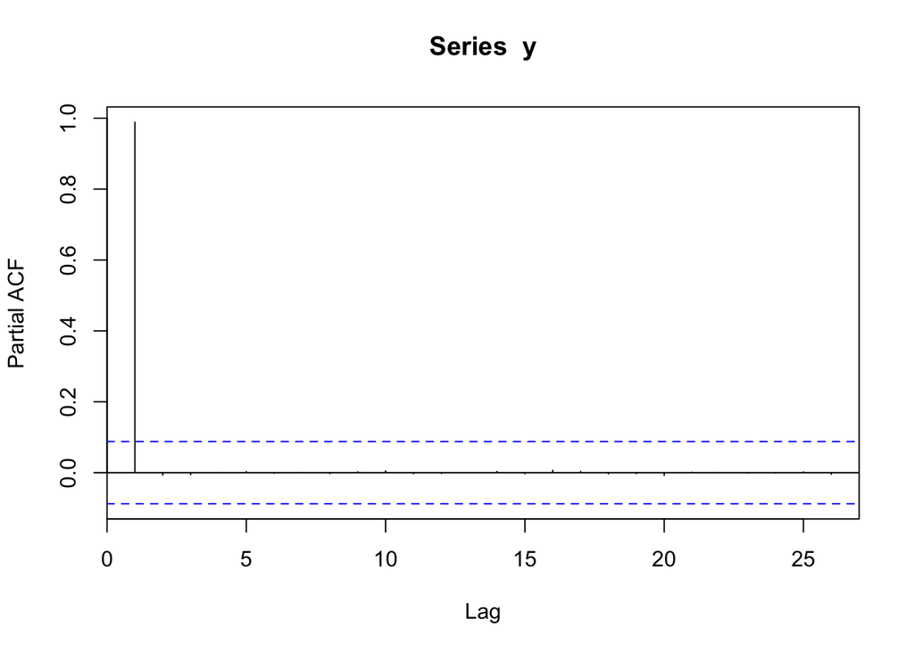

```r
pacf(y)
```

# 9 Persistent AR(1){persistent_ar1}

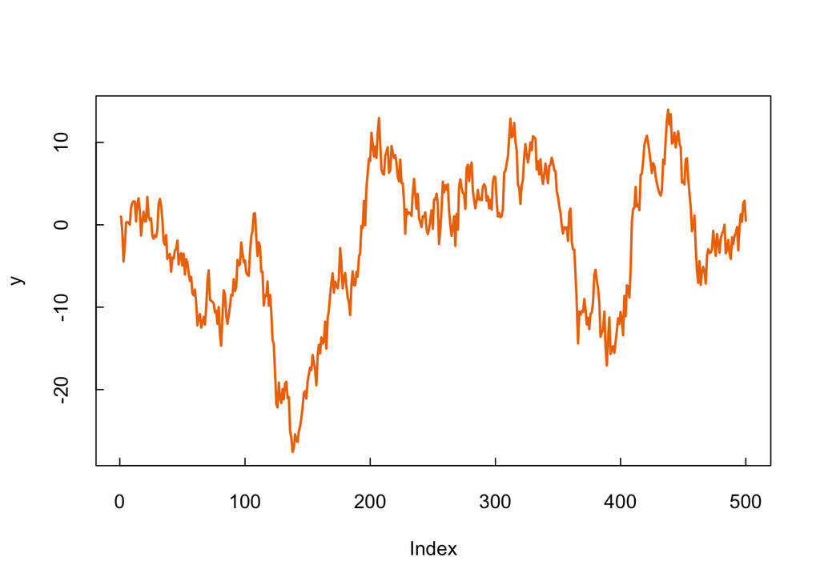

```r
phi0 <- 0.0
phi1 <- 0.97
sige <- sqrt(4)

y    <- rep(0,T)
eps  <- rnorm(T,0,sige);

y[1] <- 1;
for( t in 2:T ){
  y[t] <- phi0 + phi1*y[t-1] + eps[t]
}

plot( y , col='darkorange2' , t='l' , lwd=2 , tck = 0.02 )
```

# 10 ACF Persistent AR(1)

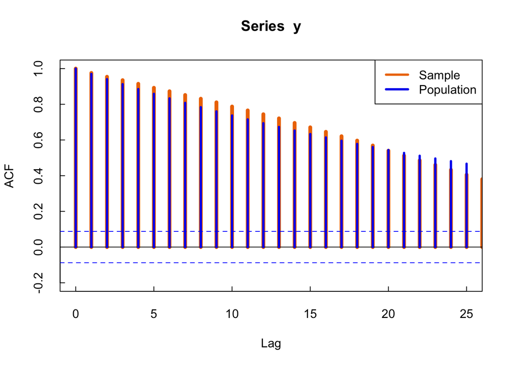

```r
acf( y , ylim=c(-0.2,1) , lwd=5 , xlim=c(0,25) , col='darkorange2' , tck=0.02)
lines( 0:25 , phi1**(0:25) , t="h" , lwd=3 , col='blue2' )
legend('topright',c('Sample','Population'),col=c('darkorange2','blue2'),lwd=3)
```

# 11 Weakly Persistent AR(1)

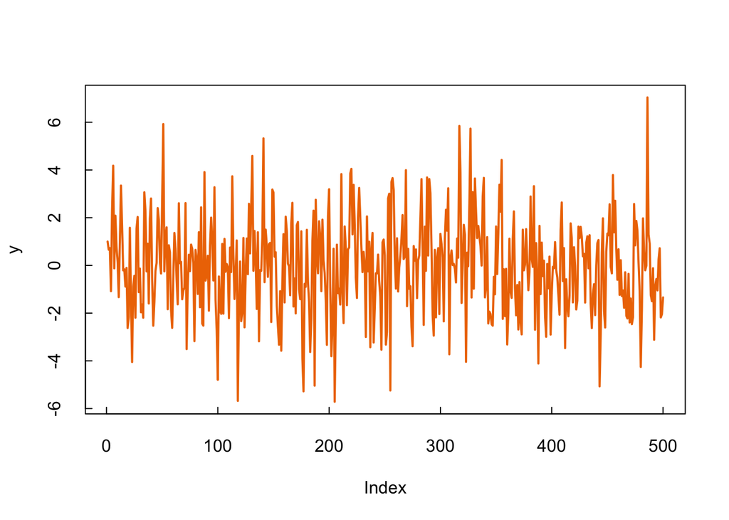

```r
phi0 <- 0.0
phi1 <- 0.20
sige <- sqrt(4)

y    <- rep(0,T)
eps  <- rnorm(T,0,sige);

y[1] <- 1;
for( t in 2:T ){
  y[t] <- phi0 + phi1*y[t-1] + eps[t]
}

plot( y , col='darkorange2' , t='l' , lwd=2 , tck = 0.02 )
```

# 12 ACF Weakly Persistent AR(1)

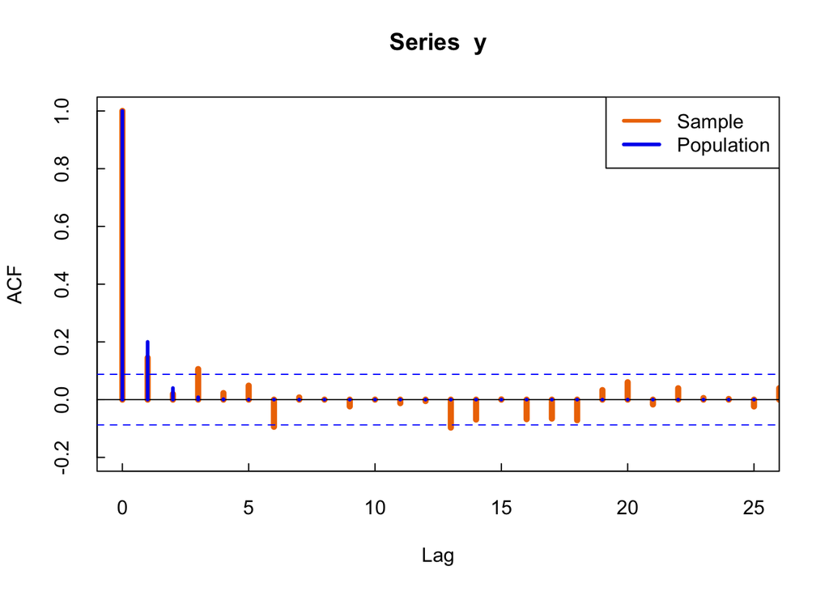

```r
acf( y , ylim=c(-0.2,1) , lwd=5 , xlim=c(0,25) , col='darkorange2' , tck=0.02)
lines( 0:25 , phi1**(0:25) , t="h" , lwd=3 , col='blue2' )
legend('topright',c('Sample','Population'),col=c('darkorange2','blue2'),lwd=3)
```